# Data Visualization in R

## Cowplot

Cowplot is a package from the lab of *C*laus *O.* *W*ilke (a man if fine tastes). It’s a simple add-on to ggplot that changes some of the underlying ggplot themes behind the scenes and generally makes everything look nicer. Cowplot is the Crock Pot of ggplot; just set it and forget it. Once you load up Cowplot, it will work it’s magic and everything will look cleaner, no additional functions required.

The beauty of Cowplot is how you can combine several plots into one larger plot with labeled subplots. For example:

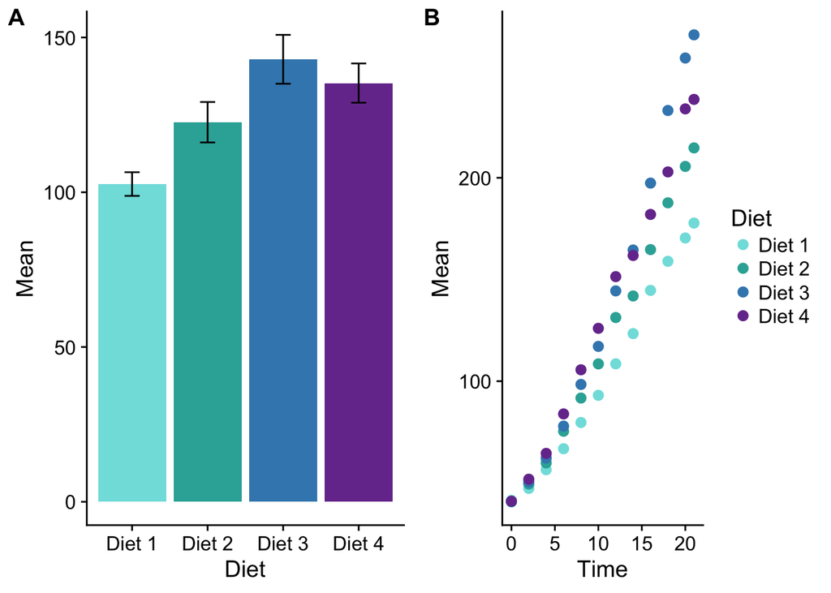

```r
# at this point, install cowplot if you don't already have it

library("cowplot")
# data frame for plot A
cw_summary <-  ChickWeight %>%
  group_by(Diet) %>%
  summarise(Mean = mean(weight),
            se = sd(weight)/(sqrt(n())))

# data frame for plot B
cw_summary2 <-  ChickWeight %>%
  group_by(Diet,Time) %>%
  summarise(Mean = mean(weight),
            se = sd(weight)/(sqrt(n())))

# plotA saved to plot object
plotA <- ggplot(cw_summary, aes(x = Diet, y = Mean, fill = Diet)) +
  geom_bar(stat = "identity", position = position_dodge()) +
  scale_fill_manual(values = jazzcup) + # this is where you manually specify a custom color palette
  geom_errorbar(aes(ymin = Mean - se, ymax = Mean + se), width = .2, position = position_dodge(.9)) +
  theme(legend.position = "none") # remove legend

# plotB saved to plot object
plotB <- ggplot(cw_summary2, aes(x = Time, y = Mean, color = Diet)) +
  geom_point(size = 2.5) +
  scale_color_manual(values = jazzcup)   # this is where you manually specify a custom color palette

# combined plot
combined_plot <- plot_grid(plotA, plotB, labels = c("A", "B"))

# We can take it a step further by aligning both plots horizontally with the align argument (use "v" for vertical)
# We can also specify the number of rows or columns
combined_plot <- plot_grid(plotA, plotB, labels = c("A", "B"), align = "h", ncol = 2)

# view plot
combined_plot
```

```r
# theme_gray() # sets default theme at the end of any more plots, just in case you want to plot like a commoner
```

Combined with some custom text themes, packages like Cowplot can result in some pretty slick plots. Thanks Claus! You can learn more about Cowplot [here](https://cran.r-project.org/web/packages/cowplot/vignettes/introduction.html).

# Minihacks

## Minihack 1: Creating ERPs from raw EEG data

Event-related potentials (ERPs) are the result of averaging many trials of raw EEG, where each trial represents raw EEG time-locked to some event. Essentially, ERPs represent the relatively consistent signal amongst all the noise. Here’s some data from subjects who performed a gambling task. The GainLoss variable represents when their gamble resulted in a loss (GainLoss == 0) or a gain (Gainloss == 1). For this minihack, you will need to: * Load the cowplot library * Read in the sample EEG * Wrangle the data so you can plot the averaged data over each timepoint for both GainLoss conditions * Include the standard error around the resulting ERPs * Flip the Y axis (negative is up, old-school style) * Pick some new colors (any colors) for the GainLoss condition and implement these in your aes call * Annotate (using a rect) the time period where you see the condition-related effect * Save the plot to a plot object and view it manually

## Minihack 2: Creating bar plots from ERPs

Recreate the plot from minihack 1, but this time as a bar plot of the average ERP voltage within the same time window you used to highlight the condition-related effect. This will require starting from the raw data and wrangling a little differently. Be sure to: * Include standard error bars * Use same colors you used in the first minihack * Save the plot to a plot object and view it manually

## Minihack 3: Using Cowplot

1. Use Cowplot to:
- Stitch together your previously saved plots
- Arrange them into one row with two columns
- Align them horizontally
- Label the first plot “A”, and the second plot “B”
- Save the plot to a plot object and view it manually

## Minihack 4: Get Creative

For this minihack, you will have the freedom to make your own graph from one of two readily available datasets. To get these datasets, install and load the package “reshape2”. Once loaded assign the pre-loaded dataframes “french_fries” and “tips” to their own variables in your global environment. french_fries is a dataframe consisting of data collected from a sensory experiment conducted at Iowa State University in 2004. The investigators were interested in the effect of using three different fryer oils had on the taste of the fries. “tips” is a dataset where one waiter recorded information about each tip he received over a period of a few months working in one restaurant. If you want more information regarding these datasets and their variables type ‘?french_fries’ or ‘?tips’. Simply make a plot that reveals something interesting in the data. Make sure to incorporate facets into your plot, make sure that it is asthetically pleasing, and make sure the graph matches the data you’re trying to depict. Be creative and have fun!

# Resources

-[Hadley Wickham’s Data Visualization Guide](http://r4ds.had.co.nz/data-visualisation.html)

-[Data Visualization Cheatsheet](https://github.com/rstudio/cheatsheets/raw/master/data-visualization-2.1.pdf)

-[Rose’s RColorBrewer Guide](https://blogs.uoregon.edu/rclub/2015/02/17/picking-pretty-plot-palates/)

-[Fill vs. Color](http://ggplot2.tidyverse.org/reference/aes_colour_fill_alpha.html)

-[ggplot Extensions](https://www.ggplot2-exts.org/ggiraph.html)

-[ggplot Cookbook](http://www.cookbook-r.com/Graphs/)

-[Style Guide for Figures](http://socviz.co/lookatdata.html#what-makes-bad-figures-bad)

-[Using Map Data](https://cran.r-project.org/web/packages/usmap/vignettes/mapping.html)